# Responsi 10 STA1211

# Analisis Regresi

Data yang digunakan adalah data `iris` yang sudah tersedia dalam R. Berikut detail peubah pada data `iris`.

```r
data("iris")
attach(iris)
str(iris)
```

```
## 'data.frame':    150 obs. of  5 variables:
##  $ Sepal.Length: num  5.1 4.9 4.7 4.6 5 5.4 4.6 5 4.4 4.9 ...
##  $ Sepal.Width : num  3.5 3 3.2 3.1 3.6 3.9 3.4 3.4 2.9 3.1 ...
##  $ Petal.Length: num  1.4 1.4 1.3 1.5 1.4 1.7 1.4 1.5 1.4 1.5 ...
##  $ Petal.Width : num  0.2 0.2 0.2 0.2 0.2 0.4 0.3 0.2 0.2 0.1 ...
##  $ Species     : Factor w/ 3 levels "setosa","versicolor",..: 1 1 1 1 1 1 1 1 1 1 ...
```

Data terdiri dari 150 amatan yang menggambarkan karakteristik bunga dari 3 (tiga) spesies bunga yaitu setosa, versicolor, dan virginica. Pada analisis regresi ini, peubah yang akan digunakan yaitu `Petal.Width` dan `Petal.Length` pada species Versicolor.

```r
versicolor<- iris[which(Species=="versicolor"),c("Petal.Length","Petal.Width")]
str(versicolor)
```

```
## 'data.frame':    50 obs. of  2 variables:
##  $ Petal.Length: num  4.7 4.5 4.9 4 4.6 4.5 4.7 3.3 4.6 3.9 ...
##  $ Petal.Width : num  1.4 1.5 1.5 1.3 1.5 1.3 1.6 1 1.3 1.4 ...
```

```r
head(versicolor)
```

```
##    Petal.Length Petal.Width
## 51          4.7         1.4
## 52          4.5         1.5
## 53          4.9         1.5
## 54          4.0         1.3
## 55          4.6         1.5
## 56          4.5         1.3
```

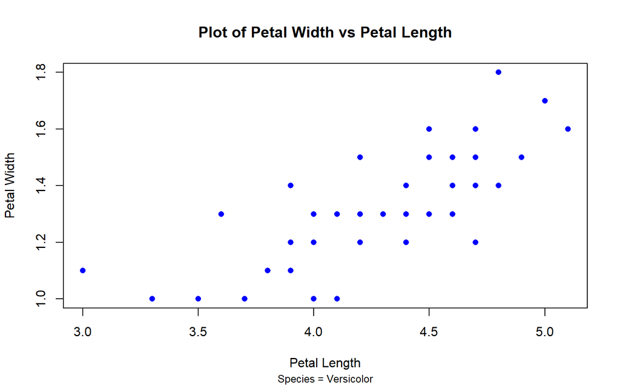

```r
plot(versicolor$Petal.Length, versicolor$Petal.Width,
     col = "blue", xlab = "Petal Length", ylab = "Petal Width", pch = 16)
title("Plot of Petal Width vs Petal Length",
     sub = "Species = Versicolor", cex.sub = 0.8)
```

Berdasarkan plot gambar diatas terlihat bahwa Petal Width dan Petal Length memiliki pola hubungan linier. Secara eksploratif terlihat bahwa semakin panjang Petal maka lebar Petal akan semakin besar. Selanjutnya, ukuran keeratan hubungan linier akan diukur menggunakan koefisien korelasi

## Korelasi

Korelasi merupakan ukuran hubungan linier antara dua peubah. Korelasi hanya mengukur hubungan linier, hubungan tidak linier tidak dapat diukur menggunakan korelasi. Nilai koefisien korelasi berada pada selang [-1,1].Parameter korelasi adalah $\rho$, sedangakan statistikanya adalah $r$. Jika nilai koefisien korelasi 0 berarti tidak ada hubungan linier antara dua peubah tersebut, dan jika nilanya mendekasi -1 atau 1 terdapat hubungan linier yang kuat antara dua peubah tersebut.

```r
cat("Koefisien Korelasi=",cor(versicolor$Petal.Length, versicolor$Petal.Width,
                                  method = "pearson") )
```

```
## Koefisien Korelasi= 0.7866681
```

## Analisis Regresi

Analisis regresi merupakan teknik analisis parametrik yang digunakan untuk memodelkan data. Selain itu, analisis regresi dapat digunakan untuk mengidentifikasi hubungan sebab akibat antara beberapa peubah. Dalam analisis regresi, dikenal dua jenis peubah:

1. Peubah respon yaitu peubah yang keberadaannya dipengaruhi oleh peubah lainnya dan dinotasikan dengan $Y$.
2. Peubah penjelas yaitu peubah yang bebas (tidak dipengaruhi oleh peubah lainnya) dan dinotasikan dengan $X$.

Model regresi linier sederhana dapat dituliskan sebagai berikut:

$Y_i = \beta_0 + \beta_i X_i + \varepsilon_i, i = 1,2,.., n$

Asumsi model regresi:

1. Nilai harapan sisaan sama dengan nol $E(\varepsilon_i)=0$
2. Ragam sisaan homogen $(Var(\varepsilon_i)=\sigma^2)$
3. Antar sisaan saling bebas
4. Sisaan menyebar normal

```r
# Pemodelan regresi
model<- lm(Petal.Width~Petal.Length, data = versicolor)
model
```

```
##
## Call:
## lm(formula = Petal.Width ~ Petal.Length, data = versicolor)
##
## Coefficients:
##  (Intercept)  Petal.Length
##     -0.08429       0.33105
```

Persamaan regresi berdasarkan hasil diatas yaitu:

$\hat{Y} = -0.084 + 0.33X$

Interpretasi $\hat{\beta}_1$ dari persamaan diatas yaitu jika panjang petal meningkat sebesar satu satuan maka lebar petal akan meningkat sebesar 0.33. Untuk $\hat{\beta}_0$ dalam kasus ini tidak dapat diinterpretasikan.

```r
# Uji hipotesis
summary(model)
```

```
##
## Call:
## lm(formula = Petal.Width ~ Petal.Length, data = versicolor)
##
## Residuals:
##       Min        1Q    Median        3Q       Max
## -0.273031 -0.073373 -0.006479  0.086271  0.295231
##
## Coefficients:
##              Estimate Std. Error t value Pr(>|t|)
## (Intercept)  -0.08429    0.16070  -0.525    0.602
## Petal.Length  0.33105    0.03750   8.828 1.27e-11 ***
## ---
## Signif. codes:  0 '***' 0.001 '**' 0.01 '*' 0.05 '.' 0.1 ' ' 1
##
## Residual standard error: 0.1234 on 48 degrees of freedom
## Multiple R-squared:  0.6188, Adjusted R-squared:  0.6109
## F-statistic: 77.93 on 1 and 48 DF,  p-value: 1.272e-11
```

Untuk pengujian hipotesis $\hat{\beta}_1$, berdasarkan hasil di atas didapatkan $p-value = 0.00 < \alpha = 0.05$ yang berarti TOLAK H0. Sehingga disimpulkan cukup bukti untuk menyatakan bahwa petal length berpengaruh terhadap petal width.

```r
# Selang kepercayaan bagi penduga parameter regresi
confint(model)
```

```
##                   2.5 %    97.5 %
## (Intercept)  -0.4074002 0.2388235
## Petal.Length  0.2556540 0.4064532
```

Selanjutnya untuk melihat sifat dari residual (sisaan) model dapat dilihat berdasarkan plot residual.

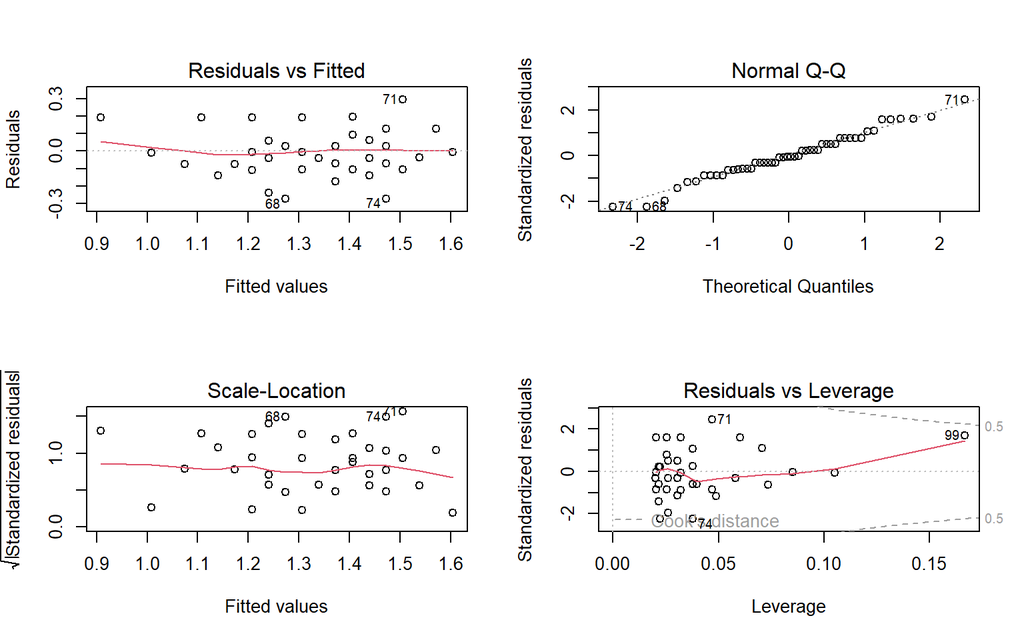

```r
# Diagnostik Model
par(mfrow = c(2,2))
plot(model)
```

Plot di atas menampilkan sifat-sifat dari residual (sisaan) model. Plot pertama dapat digunakan untuk melihat kebebasan dari residual model. Karena residual tidak memiliki pola tertentu dan garis garis merah cenderung horizontal, maka dapat dikatakan bahwa asumsi kebebasan residual terpenuhi. Selanjutnya plot quantile-quantile dapat digunakan untuk melihat kenormalan residual. Karena residual mengikuti pola garis maka dikatakan bahwa residual berdistribusi normal. Selanjutnya plot ketiga digunakan untuk melihat kehomogenan residual. Terlihat bahwa residual model tidak memiliki pola tertentu, dan garis merah cenderung mendatar, sehingga dapat dikatakan tidak ada pelanggaran asumsi kehomogenan residual.

```r
# Prediksi data
newdata1<- data.frame(Petal.Length=c(4.25,5))
predict(model, newdata = newdata1)
```

```
##        1        2
## 1.322689 1.570980
```

```r
# SK bagi dugaan (Yn+1)
predict(model, newdata = newdata1, interval = "predict")
```

```
##        fit      lwr      upr
## 1 1.322689 1.072203 1.573176
## 2 1.570980 1.314355 1.827604
```